# Normal vs. T Student Distribution Probabilities

Luis Padua

December 3, 2017

# Objective

This is a presentation to describe the Shiny application done by Luis Padua as part of the final project of course **Developing Data Products** by Coursera and John Hopkins University.  
You can access the app by https://luispadua.shinyapps.io/normaltdistributions/.

The basic idea of the app is to present the differences between Normal and T-Student probability distributions. Given a certain dataset that the user will enter one by one, the application will show how a Normal and T-Student distributions will fit to this data.

Then the user can also check the probability of a given number (from a Slider input) for each distribution.

# Interactions with the User

Inputs:

- Text Input: where the user can type new numbers to be added in the sample
- Add Data: where the user clicks to add the number on Text input to the sample
- Clear Data: where the user clear the sample
- Slider: where the user will select a number between -5sigma to 5sigma of the sample
- Type Radio button: where the user selects if he wants probability of greater or lesser than slider input

# Interactions with the User

Outputs:

- Calculated Mean
- Calculated Standard Deviation
- Number of Samples (Degrees of Freedom)
- Probability of Normal Distribution
- Probability of T Student Distribution

# Example of Sample of 10 numbers

With we have a sample of 10 numbers with mean = 0 and standard deviation = 1. The two distributions would be:

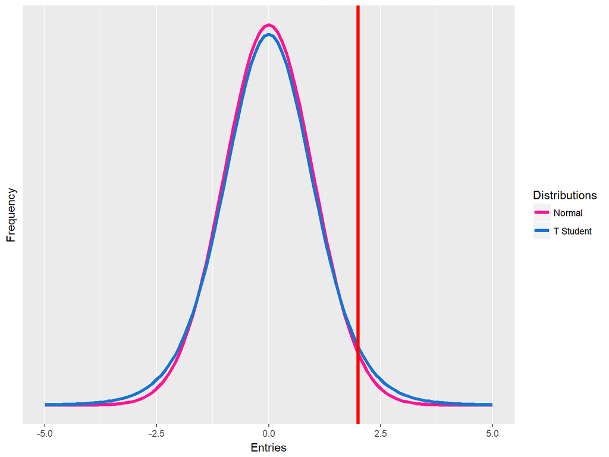

See the redline on x = 2, the probability of have a greater than 2 by normal is 0.0227501.  
And also, the probability of have a greater than 2 by T Student is 0.036694.